# TD3 - Correction

Outils de surveillance et analyses statistiques

INTECHMER - CT3 GEM

```r
library(tidyverse)
library(DT)
library(FactoMineR)
library(gridExtra)
```

## Importation des données

```r
wine = read_csv("https://archive.ics.uci.edu/ml/machine-learning-databases/wine/wine.data", col_names = FALSE)
names(wine) = c("type", "Alcohol", "Malic acid", "Ash", "Alcalinity of ash", "Magnesium",
                "Total phenols", "Flavanoids", "Nonflavanoid phenols", "Proanthocyanins",
                "Color intensity", "Hue", "OD280/OD315 of diluted wines", "Proline")
datatable(wine, rownames = FALSE, options = list(scrollX = TRUE))
```

| type | Alcohol | Malic acid | Ash | Alcalinity of ash | Magnesium | Total phenols | Flavanoids | Nonflavanoid phenols | Proanthocyanins | Color intensity | Hue | OD280/OD315 of diluted wines | Proline |
| --- | --- | --- | --- | --- | --- | --- | --- | --- | --- | --- | --- | --- | --- |
| 1 | 14.23 | 1.71 | 2.43 | 15.6 | 127 | 2.8 | 3.06 | 0.28 | 2.29 | 5.64 | 1.04 | 3.92 | 1065 |
| 1 | 13.2 | 1.78 | 2.14 | 11.2 | 100 | 2.65 | 2.76 | 0.26 | 1.28 | 4.38 | 1.05 | 3.4 | 1050 |
| 1 | 13.16 | 2.36 | 2.67 | 18.6 | 101 | 2.8 | 3.24 | 0.3 | 2.81 | 5.68 | 1.03 | 3.17 | 1185 |
| 1 | 14.37 | 1.95 | 2.5 | 16.8 | 113 | 3.85 | 3.49 | 0.24 | 2.18 | 7.8 | 0.86 | 3.45 | 1480 |
| 1 | 13.24 | 2.59 | 2.87 | 21 | 118 | 2.8 | 2.69 | 0.39 | 1.82 | 4.32 | 1.04 | 2.93 | 735 |
| 1 | 14.2 | 1.76 | 2.45 | 15.2 | 112 | 3.27 | 3.39 | 0.34 | 1.97 | 6.75 | 1.05 | 2.85 | 1450 |
| 1 | 14.39 | 1.87 | 2.45 | 14.6 | 96 | 2.5 | 2.52 | 0.3 | 1.98 | 5.25 | 1.02 | 3.58 | 1290 |
| 1 | 14.06 | 2.15 | 2.61 | 17.6 | 121 | 2.6 | 2.51 | 0.31 | 1.25 | 5.05 | 1.06 | 3.58 | 1295 |
| 1 | 14.83 | 1.64 | 2.17 | 14 | 97 | 2.8 | 2.98 | 0.29 | 1.98 | 5.2 | 1.08 | 2.85 | 1045 |
| 1 | 13.86 | 1.35 | 2.27 | 16 | 98 | 2.98 | 3.15 | 0.22 | 1.85 | 7.22 | 1.01 | 3.55 | 1045 |

[output cut: 168 more lines]

## Recherche d’une partition via CAH

Dans le dendrogramme ci-dessous, le découpage en 3 classes est le plus évident. Toutefois, on remarque qu’il est envisageable de découper en 9 classe, si on souhaite avoir des classes très restreintes et donc une vision très détaillée.

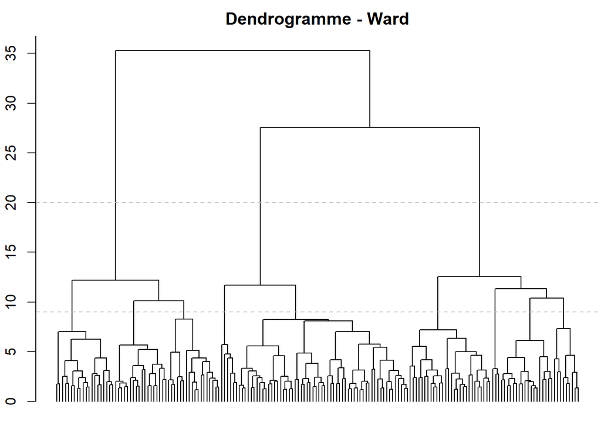

```r
cah = wine[,-1] %>%
  scale() %>%
  dist() %>%
  hclust(method = "ward.D2")

par(mar = c(0, 2, 2, 0) + .1)
plot(cah, hang = -1, labels = FALSE, main = "Dendrogramme - Ward")
abline(h = 20, lty = 2, col = "gray")
abline(h = 9, lty = 2, col = "gray")
```

### En choississant 3 classes

On remarque de nettes différences entre les 3 classes.

```r
cah_z3 = cutree(cah, 3)

cah_centre3 = wine[,-1] %>%
  mutate(classe = cah_z3) %>%
  group_by(classe) %>%
  summarise_all(mean) %>%
  pivot_longer(-classe) %>%
  pivot_wider(names_from = classe, values_from = value)

datatable(cah_centre3, rownames = FALSE,
          options = list(paging = F, searching = FALSE)) %>%
  formatRound(2:4, digits = 2)
```

| name | 1 | 2 | 3 |
| --- | --- | --- | --- |
| Alcohol | 13.66921875 | 12.20396551724138 | 13.06160714285714 |
| Malic acid | 1.97 | 1.938965517241379 | 3.166607142857143 |
| Ash | 2.463125 | 2.215172413793103 | 2.412857142857143 |
| Alcalinity of ash | 17.528125 | 20.20862068965517 | 21.00357142857143 |
| Magnesium | 106.15625 | 92.55172413793103 | 99.85714285714286 |
| Total phenols | 2.85 | 2.262931034482758 | 1.694285714285714 |
| Flavanoids | 3.0096875 | 2.088103448275862 | 0.8478571428571429 |
| Nonflavanoid phenols | 0.29109375 | 0.3553448275862069 | 0.4494642857142857 |
| Proanthocyanins | 1.908125 | 1.686551724137931 | 1.129285714285714 |
| Color intensity | 5.45 | 2.895344827586207 | 6.850178553571428 |

[output cut: 3 more lines]

La partition obtenue par la CAH est très proche de la répartition des types de vin, à part pour 13 (5 + 8) vins mal classés (CAH en ligne et type de départ en colonne)

```r
table(cah_z3, wine$type)
```

```
##
## cah_z3  1  2  3
##      1 59  5  0
##      2  0 58  0
##      3  0  8 48
```

### En choississant 9 classes

La lecture est ici plus ardue et exige une bonne connaissance du domaine.

```r
cah_z9 = cutree(cah, 9)

cah_centre9 = wine[,-1] %>%
  mutate(classe = cah_z9) %>%
  group_by(classe) %>%
  summarise_all(mean) %>%
  pivot_longer(-classe) %>%
  pivot_wider(names_from = classe, values_from = value)

datatable(cah_centre9, rownames = FALSE,
          options = list(paging = F, searching = FALSE)) %>%
  formatRound(2:10, digits = 2)
```

| name | 1 | 2 | 3 | 4 | 5 | 6 | 7 | 8 | 9 |
| --- | --- | --- | --- | --- | --- | --- | --- | --- | --- |
| Alcohol | 13.72862068965517 | 13.095 | 12.33277777777778 | 12.61777777777778 | 11.99777777777778 | 12.17321428571429 | 12.33666666666667 | 13.095 | 13.431 |
| Malic acid | 1.970862068965517 | 1.961666666666666 | 1.524444444444444 | 2.316666666666667 | 2.42 | 2.126428571428571 | 1.233333333333333 | 4.068888888888889 | 3.1195 |
| Ash | 2.418103448275862 | 2.898333333333333 | 1.958888888888889 | 2.291111111111111 | 2.288888888888889 | 2.382857142857143 | 1.966666666666667 | 2.440555555555556 | 2.4975 |
| Alcalinity of ash | 16.77413793103448 | 24.81666666666667 | 17.93333333333333 | 19.23333333333333 | 19.83333333333333 | 22.15 | 16.86666666666667 | 21.61111111111111 | 22.05 |
| Magnesium | 105.1896551724138 | 115.5 | 88.83333333333333 | 104.2777777777778 | 92.77777777777777 | 88.75 | 149.6666666666667 | 92.44444444444444 | 102.55 |
| Total phenols | 2.837758620689655 | 2.968333333333333 | 2.164444444444444 | 1.594444444444444 | 2.988888888888889 | 2.112142857142857 | 2.083333333333333 | 1.696666666666667 | 1.782 |
| Flavanoids | 2.99051724137931 | 3.195 | 1.914444444444444 | 0.9294444444444444 | 2.796666666666667 | 2.002857142857143 | 1.8 | 0.6761111111111111 | 0.929 |
| Nonflavanoid phenols | 0.2846551724137931 | 0.3533333333333333 | 0.2955555555555556 | 0.3994444444444444 | 0.2377777777777778 | 0.4407142857142857 | 0.27 | 0.5311111111111111 | 0.421 |
| Proanthocyanins | 1.912413793103448 | 1.866666666666667 | 1.414444444444444 | 0.9555555555555555 | 2.293333333333333 | 1.542142857142857 | 2.846666666666667 | 0.9777777777777777 | 1.422 |
| Color intensity | 5.580517241379311 | 4.188333333333333 | 3.052777777777778 | 4.962777777777778 | 3.267777777777778 | 2.668571428571429 | 2.95 | 5.688888888888889 | 9.59399995 |

[output cut: 3 more lines]

Les classes obtenues sont parfois très petites (3 vins au minimum), et il y a tout de même quelques classes sur 2 types de vin.

```r
table(cah_z9, wine$type)
```

```
##
## cah_z9  1  2  3
##      1 56  2  0
##      2  3  3  0
##      3  0 18  0
##      4  0  6 12
##      5  0  9  0
##      6  0 28  0
##      7  0  3  0
##      8  0  2 16
##      9  0  0 20
```

## Recherche d’une partition via $k$-means

On voit très bien dans les graphiques ci-dessous que le choix de 3 classes s’impose.

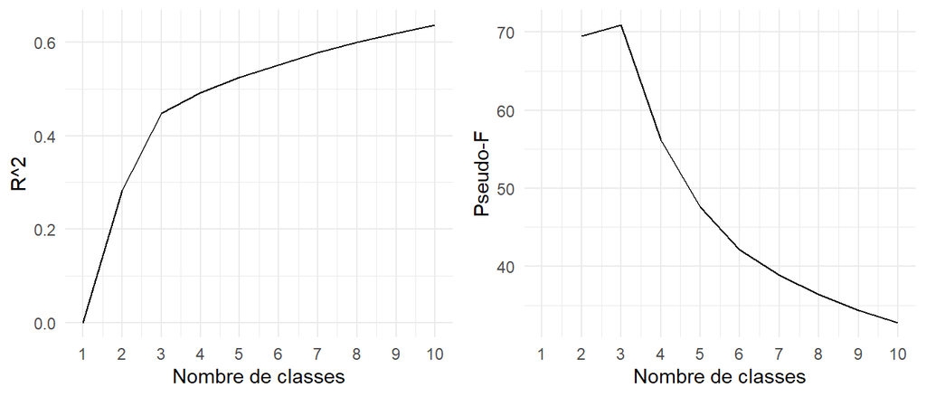

```r
res = data.frame(nbclust = NA, I = NA, W = NA, B = NA)
for (k in 1:10) {
  km = kmeans(scale(wine[,-1]), centers = k, nstart = 30)
  res[k,] = c(k, km$totss, km$tot.withinss, km$betweenss)
}
res = res %>%
  mutate(r2 = B / I) %>%
  mutate(psf = (r2 / (nbclust - 1)) / ((1 - r2) / (nrow(wine) - nbclust))) %>%
  mutate_all(~ ifelse(is.infinite(.x), NA, .x))

g_r2 = ggplot(res, aes(nbclust, r2)) +
  geom_line() +
  scale_x_continuous(breaks = 1:10) +
  labs(x = "Nombre de classes", y = "R^2") +
  theme_minimal()
g_psf = ggplot(res, aes(nbclust, psf)) +
  geom_line() +
  scale_x_continuous(breaks = 1:10) +
  labs(x = "Nombre de classes", y = "Pseudo-F") +
  theme_minimal()
grid.arrange(g_r2, g_psf, ncol = 2)
```

Les différences entre classes sont ici aussi très nettes.

```r
km3 = kmeans(scale(wine[,-1]), centers = 3)

km3_centres = wine[,-1] %>%
  mutate(classe = km3$cluster) %>%
  group_by(classe) %>%
  summarise_all(mean) %>%
  pivot_longer(-classe) %>%
  pivot_wider(names_from = classe, values_from = value)
datatable(km3_centres, rownames = FALSE,
          options = list(paging = F, searching = FALSE)) %>%
  formatRound(columns = 2:4, digits = 2)
```

| name | 1 | 2 | 3 |
| --- | --- | --- | --- |
| Alcohol | 13.67677419354839 | 13.13411764705882 | 12.25092307692308 |
| Malic acid | 1.997903225806452 | 3.307254901960784 | 1.897384615384615 |
| Ash | 2.466290322580645 | 2.417647058823529 | 2.231230769230769 |
| Alcalinity of ash | 17.46290322580645 | 21.24117647058824 | 20.06307692307692 |
| Magnesium | 107.9677419354839 | 98.66666666666667 | 92.73846153846154 |
| Total phenols | 2.84758064516129 | 1.683921568627451 | 2.247692307692308 |
| Flavanoids | 3.003225806451613 | 0.8188235294117647 | 2.05 |
| Nonflavanoid phenols | 0.2920967741935484 | 0.4519607843137255 | 0.3576923076923077 |
| Proanthocyanins | 1.922096774193548 | 1.145882352941177 | 1.624153846153846 |
| Color intensity | 5.453548387096774 | 7.234705862745098 | 2.973076923076923 |

[output cut: 3 more lines]

On retrouve très bien la répartition en 3 types de vin, avec toutefois 6 (3 + 3) vins *mal classés*.

```r
table(km3$cluster, wine$type)
```

```
##
##      1  2  3
##   1 59  3  0
##   2  0  3 48
##   3  0 65  0
```

## Comparaison des deux partitions

Les partitions sont globalement les mêmes, avec quelques différences (pour un total de 9 vins classés différement).

```r
table(cah_z3, km3$cluster)
```

```
##
## cah_z3  1  2  3
##      1 61  0  3
##      2  1  0 57
##      3  0 51  5
```

## Représentation sur l’ACP

Il est très clair que les classes obtenus sont globalement les mêmes (ne pas tenir compte des couleurs qui ne signifient rien). Les classes sont tout de même mieux séparées par $k$-means (ceci est globalement toujours vrai).

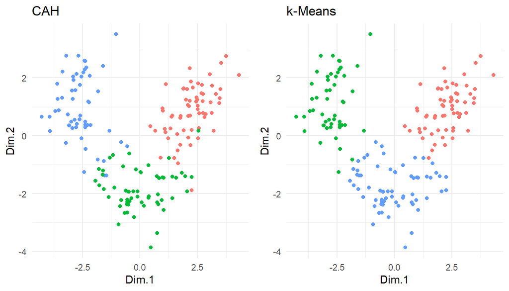

```r
acp = PCA(wine[,-1], graph = FALSE)

g_cah = acp$ind$coord %>%
  data.frame() %>%
  mutate(classe = as.character(cah_z3)) %>%
  ggplot(aes(Dim.1, Dim.2, color = classe)) +
  geom_point(show.legend = FALSE) +
  theme_minimal() +
  ggtitle("CAH")
g_kmeans = acp$ind$coord %>%
  data.frame() %>%
  mutate(classe = as.character(km3$cluster)) %>%
  ggplot(aes(Dim.1, Dim.2, color = classe)) +
  geom_point(show.legend = FALSE) +
  theme_minimal() +
  ggtitle("k-Means")

grid.arrange(g_cah, g_kmeans, ncol = 2)
```